### Introduction to the tasks

The capstone project scope is to design an application able to predict next word(s) based on a incomplete sentence typed by the user. A corpora of three files with text data from twitter, blog and news were provided and will be used to create the prediction model. The application will be developed in R using Shiny package.

The two main tasks of this milestone report are:

- Performing an exploratory analysis of the corpora provided, understand the distribution of words and relationship between them.
- Briefly summarize plans for creating the prediction algorithm and Shiny app.

### Load corpora text files

The corpora are collected from publicly available sources by a web crawler. The crawler checks for language, so as to mainly get texts consisting of the desired language.

We are only loading texts in English language.

```r
path <- ("C:/Users/Marco/Documents/ds_specialization_github/datasciencecoursera/Capstone Project/swiftkey_data/en_US/")
blogs <- readLines(paste0(path,"en_US.blogs.txt"), encoding = "UTF-8")
news <- readLines(paste0(path,"en_US.news.txt"), encoding = "UTF-8")
twitter <- readLines(paste0(path,"en_US.twitter.txt"), encoding = "UTF-8")
```

### Sampling

Given the big size of datasets, we are going to take a sample for each of them. The idea is to have a **smaller and representative subset** on which we can perform qicker analysis and build statistical models eventually.

```r
sample_2_per <- function (x) {sample(x , length(x)*0.02, replace = F)}
set.seed(15)
blogs_s <- sample_2_per(blogs)
news_s <- sample_2_per(news)
twitter_s <- sample_2_per(twitter)

# We can remove original text files loaded into R to free up memory
library(pryr)
mem_used()
rm(blogs, news, twitter)
mem_used()   # we have much more free memory now
```

### Initial cleaning: remove non-ASCII character

First of all we are going to remove non-ASCII characters e.g. symbols, emoticons, etc. which are often present in social networks messages.

```r
# create a function to convert to ascii
conv_to_ascii <- function(x) {
  to_ascii <- iconv(x, "latin1", "ASCII", sub="")
  return(to_ascii)
}

blogs_s <- conv_to_ascii(blogs_s)
news_s <- conv_to_ascii(news_s)
twitter_s <- conv_to_ascii(twitter_s)
```

### Combine the 3 samples in one dataset

```r
all_samples <- c(blogs_s, news_s, twitter_s)
```

### Load text mining libraries

After several attempts using `tm` and `RWeka`, due mainly to performance issues, I have decided to explore `**quanteda**` library.

I am also going to make use of the recently built `tidytext` library to generate some visualizations.

```r
library("quanteda")
library("tidytext")
```

### Create a Corpus

```r
my_corpus <- corpus(all_samples)

summary(my_corpus, 3)
```

```
## Corpus consisting of 66732 documents, showing 3 documents:
##
##   Text Types Tokens Sentences
##  text1    50     65         2
##  text2    16     18         1
##  text3    72    124         6
##
## Source:  C:/Users/Marco/Dropbox/Coursera/Data Science Specialization - JHU/Capstone Project/week2/* on x86-64 by Marco
## Created: Sun Oct 29 19:02:20 2017
## Notes:
```

```r
# or to extract for example just the 2nd text of the corpus:
# texts(my_corpus)[2]
```

### Cleaning the data

I am creating a sparse document-feature matrix and apply the following cleaning operations:

- convert everything to **lower case** for consistency.
- **stemming** to reduce inflectional forms and derivated forms to their root or “stem” form (e.g. organize, organizes, and organizing; democracy, democratic, democratization).
- remove **stopwords**
- remove **profanity words**

```r
profanity <- read.table("swearWords.csv", sep=",")

my_corpus_cleaned <- dfm(all_samples, tolower = T,
                         stem = T, remove_punct=T,remove_numbers=T,
                         remove = c(stopwords("english"), profanity),
                         dictionary = NULL, verbose=TRUE
                         )
```

### Identify most frequent words

```r
top_words <- topfeatures(my_corpus_cleaned, 50)
```

Plotting text dataset as a worldcloud. Size of words are proportional to their frequency.

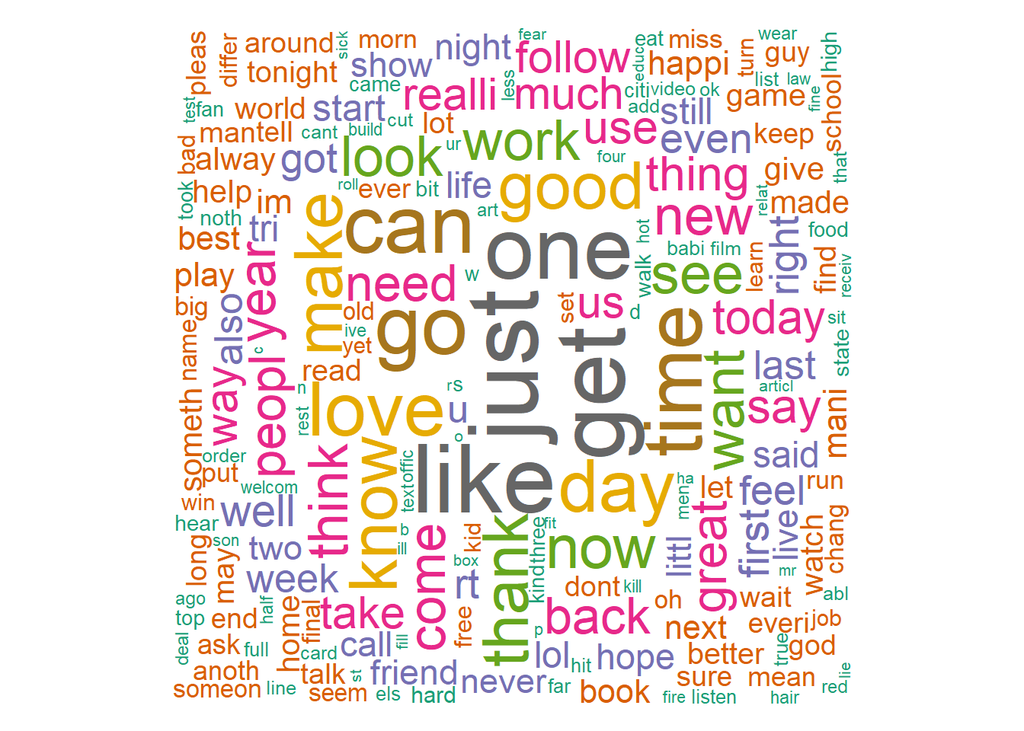

```r
textplot_wordcloud(my_corpus_cleaned, min.freq = 200, random.order = FALSE,
                   rot.per = .25, colors = RColorBrewer::brewer.pal(8,"Dark2"))
```

### How many unique words do we need to cover 50% and 90% of all document?

Please note I am doing this analysis using the combined sample created previously wich include only a 2% subset of the original data.

From the cleaned corpus generated above I know there is a total of 50713 features inside.

```r
library(dplyr)
all_features <- topfeatures(my_corpus_cleaned, 50713)
all_features <- as.data.frame(all_features) %>% rename (freq= all_features)

all_features <- all_features %>%
                  mutate(word=row.names(all_features), total=sum(freq),
                  per=freq/total, cum=cumsum(per)) %>%
                  select (word, freq, cum)

cum50 <- which(all_features$cum >= 0.5)[1]
cum50 / 50713
```

```
## [1] 0.01031294
```

```r
cum90 <- which(all_features$cum >= 0.9)[1]
cum90 / 50713
```

```
## [1] 0.1483446
```

*Additional analysis*: it would be interesting to break down this analysis for **blogs vs news vs twitter** to see if for example the % of unique words needed is even lower for twitter compared to blogs or news (hypothesis: social networds have more restricted vocabulary while news might present a much richer vocabulary).

### Create ngrams

To understand relationships between words I am creatin several grams. Grams are sequences of words that are found inside wider sequences of words. I’ll be creating bigrams (2 words sequences), trigrams (3 words) and fougrams (4 words).

In `quanteda` I can still use the `dfm()` function and use the argument `ngrams` to specify the number of words in the sequence.

```r
# Create a function since the only parameter I might have to change is the number of grams
create_gram <- function (x, n) {
  gram <- dfm(x, ngrams=n, concatenator=" ", tolower = T,
            stem = T,  remove_punct=T,  remove_numbers=T,
            remove = stopwords("english"), dictionary = NULL, verbose=TRUE)
  return(gram)
}

bigrams <- create_gram(my_corpus, 2)
trigrams <- create_gram(my_corpus, 3)
fourgrams <- create_gram(my_corpus, 4)
```

### Most frequent bigrams

```r
top10_bigrams <- topfeatures(bigrams, 10)
kable(as.data.frame(top10_bigrams))
```

|  | top10_bigrams |
| --- | --- |
| of the | 5130 |
| in the | 4959 |
| to the | 2854 |
| for the | 2700 |
| on the | 2526 |
| to be | 2438 |
| at the | 1809 |
| i have | 1656 |
| want to | 1580 |
| go to | 1568 |

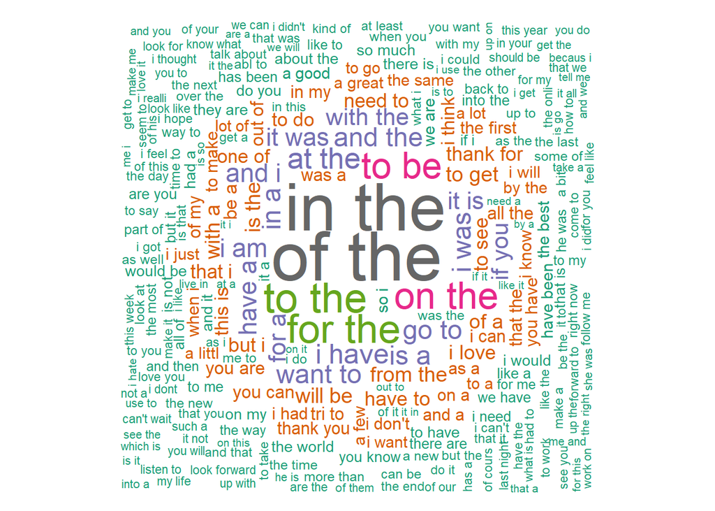

```r
textplot_wordcloud(bigrams, min.freq = 200, random.order = FALSE,
                   rot.per = .25, colors = RColorBrewer::brewer.pal(8,"Dark2"))
```

We can also visualize network of bigrams and understand all the relationships between words simultaneously. To make the visualization we will use the ggraph package as suggested in the book [Text Mining with R](http://tidytextmining.com/ngrams.html#visualizing-a-network-of-bigrams-with-ggraph).

First I need to get data into a tidy format (data frame where each word is a column)

```r
library(tidyr)
top100_bigrams <- topfeatures(bigrams, 100)
test <- as.data.frame(top100_bigrams)
bigrams_tidy <- data.frame(row.names(test), test$top100_bigrams)
names(bigrams_tidy) <- c("words", "freq")
bigrams_tidy <- separate(bigrams_tidy, words, into = c("word1", "word2"), sep = " ")
kable(head(bigrams_tidy))
```

| word1 | word2 | freq |
| --- | --- | --- |
| of | the | 5130 |
| in | the | 4959 |
| to | the | 2854 |
| for | the | 2700 |
| on | the | 2526 |
| to | be | 2438 |

Now we can build the network viz (I am plotting just the top 100 bigrams).

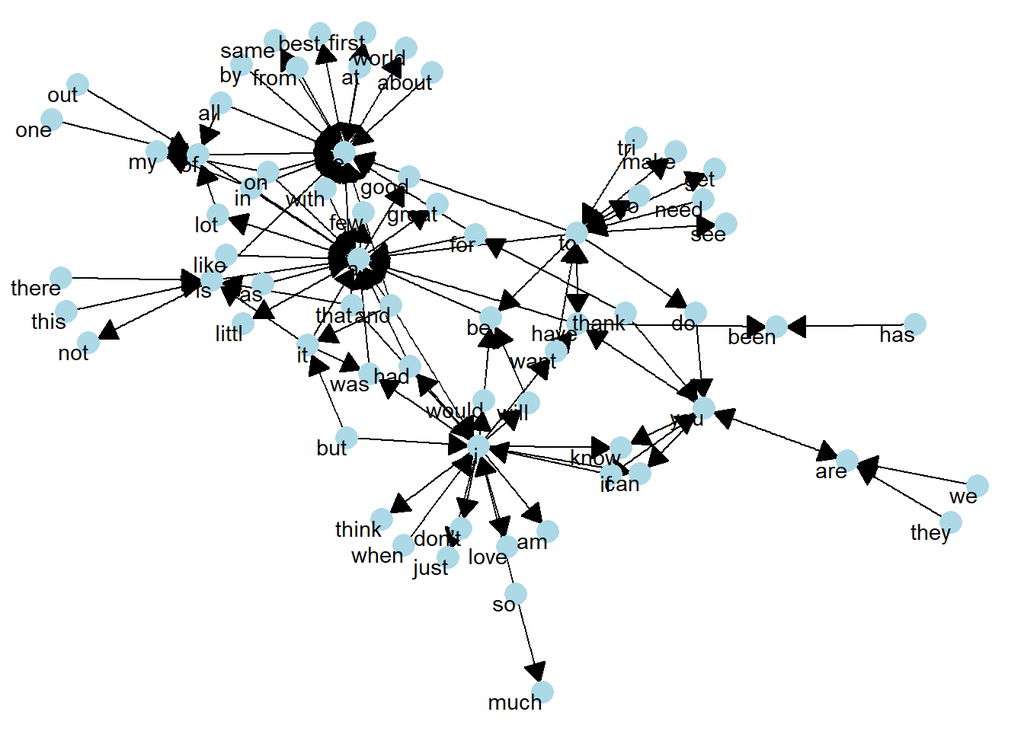

```r
library(igraph)
library(ggraph)

bigram_graph <- bigrams_tidy %>%
  graph_from_data_frame()

a <- grid::arrow(type = "closed", length = unit(.15, "inches"))
ggraph(bigram_graph, layout = "fr") +
  geom_edge_link(show.legend = FALSE,arrow = a, end_cap = circle(.07, 'inches')) +
  geom_node_point(color = "lightblue", size = 5) +
  geom_node_text(aes(label = name), vjust = 1, hjust = 1) +
  theme_void()
```

As we might expected, the network shows that words like “I”, “you”, “to”, “the” represent key node around which sentences are built upon.

### Most frequent trigrams

```r
top10_trigrams <- topfeatures(trigrams, 10)
kable(as.data.frame(top10_trigrams))
```

|  | top10_trigrams |
| --- | --- |
| thank for the | 510 |
| a lot of | 395 |
| i want to | 395 |
| one of the | 389 |
| look forward to | 322 |
| go to be | 294 |
| to be a | 275 |
| be abl to | 227 |
| it was a | 227 |
| i have to | 223 |

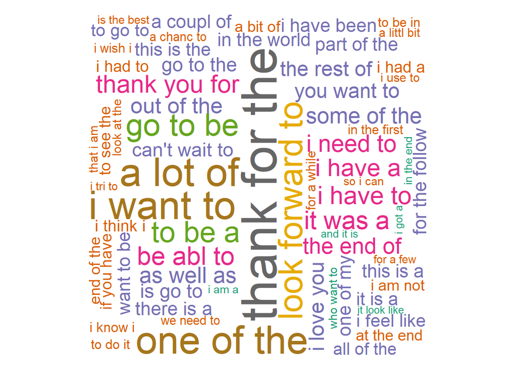

```r
textplot_wordcloud(trigrams, min.freq = 50, random.order = FALSE,
                   rot.per = .25, colors = RColorBrewer::brewer.pal(8,"Dark2"))
```

### Most frequent fourgrams

```r
top10_fourgrams <- topfeatures(fourgrams, 10)
kable(as.data.frame(top10_fourgrams))
```

|  | top10_fourgrams |
| --- | --- |
| thank for the follow | 119 |
| the rest of the | 100 |
| the end of the | 91 |
| is go to be | 81 |
| thank for the rt | 80 |
| for the first time | 79 |
| at the end of | 78 |
| when it come to | 69 |
| in the middl of | 67 |
| if you want to | 64 |

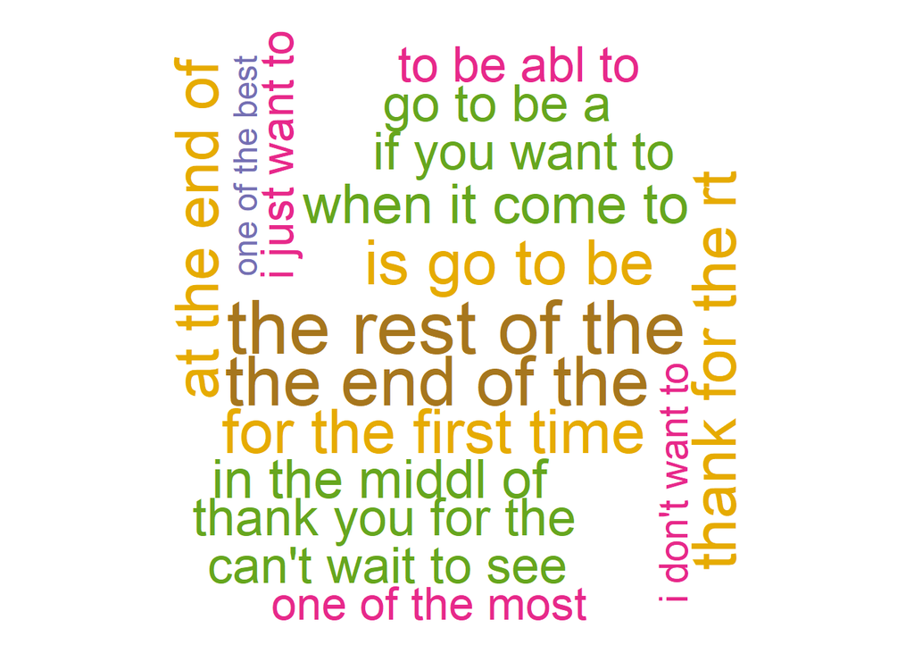

```r
textplot_wordcloud(fourgrams, min.freq = 30, random.order = FALSE,
                   rot.per = .25, colors = RColorBrewer::brewer.pal(8,"Dark2"))
```

### Plan for prediction algorithm

1. Data preparation and ngrams creation will be done outside the app, for performance reasons (might do further cleaning as profanity filter doesn’t work properly).
2. Given that 14% of unique words cover over 90% of the document, we will probably keep only ngrams with a specified minimum frequency.
3. Load ngrams text files.
4. User inputs a word. Whenever he clicks on submit (or enter) the input will be read.
5. Prediction algorithm takes the input and will output next word(s) prediction to the user (TBC how many words to show).
6. The user might choose how many next words to have predicted (e.g. 1 to 3 max)
7. Algorithm steps: I might use the Katz backoff algorithm to make the predictions. The steps could be as follows:
- search first within the fourgrams file and show the most probable match (look for last 3 words typed by the user).
- if no match is found, back off to trigrams (look for last 2 words typed by the user);
- if not match is found, back off to bigrams (look for last word typed by the user);
- if not match is found, back off to one gram (return word(s) with highest frequency).